# Accuracy, Uncertainty, Bias

This pages plots the graphs of the main results concerning accuracy, uncertainty and bias of the scenarios reports.

```r
knitr::opts_chunk$set(message=F, warning=F, fig.align = "center",  dev='png')

library(tidyverse) #loads multiple packages (see https://tidyverse.tidyverse.org/)

#core tidyverse packages loaded:
# ggplot2, for data visualisation. https://ggplot2.tidyverse.org/
# dplyr, for data manipulation. https://dplyr.tidyverse.org/
# tidyr, for data tidying. https://tidyr.tidyverse.org/
# readr, for data import. https://readr.tidyverse.org/
# purrr, for functional programming. https://purrr.tidyverse.org/
# tibble, for tibbles, a modern re-imagining of data frames. https://tibble.tidyverse.org/
# stringr, for strings. https://stringr.tidyverse.org/
# forcats, for factors. https://forcats.tidyverse.org/
# lubridate, for date/times. https://lubridate.tidyverse.org/

#also loads the following packages (less frequently used):
# Working with specific types of vectors:
#     hms, for times. https://hms.tidyverse.org/
# Importing other types of data:
#     feather, for sharing with Python and other languages. https://github.com/wesm/feather
#     haven, for SPSS, SAS and Stata files. https://haven.tidyverse.org/
#     httr, for web apis. https://httr.r-lib.org/
#     jsonlite for JSON. https://arxiv.org/abs/1403.2805
#     readxl, for .xls and .xlsx files. https://readxl.tidyverse.org/
#     rvest, for web scraping. https://rvest.tidyverse.org/
#     xml2, for XML. https://xml2.r-lib.org/
# Modelling
#     modelr, for modelling within a pipeline. https://modelr.tidyverse.org/
#     broom, for turning models into tidy data. https://broom.tidymodels.org/

# Use the conflicted package (<http://conflicted.r-lib.org/>) to force all conflicts to become errors


library(cowplot) #for plot_grid()
library(ggbeeswarm) #for geom_beeswarm()
library(ggnewscale) #to reset manual scale in ggplot when multiple fill scales
library(ggpubr) # for visual stat test on box plots

#set theme for graphs
theme_set(
  theme_classic() +
  theme(
    panel.grid.major.y = element_line(color = "gray", linewidth = 0.4), #no vertical lines by default
    #panel.grid.minor.y = element_line(color = "gray", linewidth = 0.1),
    text = element_text(family = "Times New Roman"), #default font
    plot.title = element_text(face="bold"), #graphs titles in bolds
    )
  )

# epidemic peaks during 1st wave
max_new_hosp <- 3036 #historical peak of new hospitalizations
max_ICU_beds <- 6937 #historical peak of ICU beds
dpi_resolution <- 500 #default dpi resolution for our png graphs

#set seed for reproducibility of graphs with small random offset of points to avoid overplotting
set.seed(123)

# Get the directory of the R Markdown file and set the working directory to the file location
#md_dir <- dirname(rstudioapi::getActiveDocumentContext()$path)
#setwd(md_dir)
```

# Prepare data

We load the files generated from the jupyter notebooks, which computed all the errors metrics (mean absolute error, mean error, mean absolute percentage error, uncertainty…).

TBD: harmonizer les errors metrics !

```r
# old error metrics dfs
errors_old <-
  read_csv('results/error_metrics_stratified_by_scenario_types.csv') %>%
  mutate(
    #to have percentages on graphs
    MAE = MAE/100,
    ME = ME/100,
    `Max Error` = `Max Error`/100,
    MAPE = MAPE/100
    ) %>%
  rename(
    #for more explicit column names
    scenario_ID = ...1,
    scenario_type = scenario,
    `Mean Absolute Error (%)` = MAE,
    `Mean Error (%)` = ME,
    `Maximum Error (%)` = `Max Error`,
    `Mean Absolute Percentage Error` = MAPE,
    `Mean Absolute Error (beds)` = `MAE (beds)`,
    `Maximum Error (beds)` = `Max error (beds)`
    ) %>%
  mutate(
    #report ID with date of publication
    scenario_ID = as.Date(gsub("Scenario: ", "", scenario_ID)),
    #more explicit scenarios denomination
    scenario_type = case_when(
      scenario_type == "Optimist" ~ "best case",
      scenario_type == "Pessimist" ~ "worst case",
      scenario_type == "Median" ~ "median"
      ),
    #more explicit endpoint name
    endpoints = case_when(
      endpoints=="ICU"~"Intensive Care Units",
      endpoints=="New hosp."~"New Hospitalizations"
      )
    )

#order scenarios levels for graph order
errors_old$scenario_type <- factor(
  errors_old$scenario_type,
  levels = c(
    'worst case',
    'median',
    'best case'
  )
)
```

error metric old style with baselines

```r
errors_new <-
  read_csv("results/error_metrics_stratified_by_scenario_types_with_baselines.csv", show_col_types = FALSE) %>%
  mutate(
    # to have proportions on graphs (for percent labels)
    MAE = MAE / 100,
    ME = ME / 100,
    `Max Error` = `Max Error` / 100,
    MAPE = MAPE / 100
  ) %>%
  rename(
    # more explicit column names
    scenario_ID = ...1,
    scenario_type = scenario,
    `Mean Absolute Error (%)` = MAE,
    `Mean Error (%)` = ME,
    `Maximum Error (%)` = `Max Error`,
    `Mean Absolute Percentage Error` = MAPE,
    `Mean Absolute Error (beds)` = `MAE (beds)`,
    `Maximum Error (beds)` = `Max error (beds)`
  ) %>%
  mutate(
    # report ID with date of publication (YYYY/MM/DD is inside the string)
    scenario_ID = as.Date(gsub("^Scenario: ([0-9]{4}/[0-9]{2}/[0-9]{2}).*$", "\\1", scenario_ID),
                          format = "%Y/%m/%d"),
    # more explicit scenario/baseline denomination
    scenario_type = case_when(
      scenario_type == "Optimist" ~ "best case",
      scenario_type == "Pessimist" ~ "worst case",
      scenario_type == "Median" ~ "median",
      scenario_type == "Constant Baseline" ~ "constant",
      scenario_type == "Damped trend" ~ "damped trend",
      TRUE ~ scenario_type
    ),
    # more explicit endpoint name
    endpoints = case_when(
      endpoints == "ICU" ~ "Intensive Care Units",
      endpoints == "New hosp." ~ "New Hospitalizations",
      TRUE ~ endpoints
    )
  )

# order scenario levels for graph order
errors_new$scenario_type <- factor(
  errors_new$scenario_type,
  levels = c("worst case", "median", "best case", "constant", "damped trend")
)
```

errors metrics

TBD: gérer colonnes peak et Average uncertainty (beds)

```r
errors <- read_csv('results/error_metrics_with_baselines.csv') %>%
  # 1) Parse the id column into scenario_ID + endpoint (robust to variable spacing)
  rename(raw_id = ...1) %>%
  mutate(
    raw_id = gsub("^Scenario:\\s*", "", raw_id),
    # scenario_ID is the first token (YYYY/MM/DD)
    scenario_ID = as.Date(sub(" .*", "", raw_id), format = "%Y/%m/%d"),
    # endpoint is whatever remains after the date (trimmed)
    endpoint = trimws(sub("^[0-9]{4}/[0-9]{2}/[0-9]{2}\\s*", "", raw_id)),
    # harmonize endpoint names to match temporal
    endpoint = case_when(
      grepl("^ICU", endpoint) ~ "Intensive Care Units",
      grepl("^New hosp\\.", endpoint) ~ "New Hospitalizations",
      TRUE ~ endpoint
    ),
    # Denominator for normalization
    denom = case_when(
      endpoint == "Intensive Care Units" ~ max_ICU_beds,
      endpoint == "New Hospitalizations" ~ max_new_hosp,
      TRUE ~ NA_real_
    )
  ) %>%
  # 2) Recompute MAE normalized from beds columns (and drop old % columns)
  mutate(
    `MAE (median, normalized)`       = `MAE (median, beds)` / denom,
    `MAE (low, normalized)`          = `MAE (low, beds)` / denom,
    `MAE (high, normalized)`         = `MAE (high, beds)` / denom,
    `MAE (constant, normalized)`     = `MAE (constant, beds)` / denom,
    `MAE (damped_trend, normalized)` = `MAE (damped_trend, beds)` / denom
  ) %>%
  select(-denom) %>%
  # Drop the existing MAE % columns (you said you prefer recomputing consistently)
  select(-`MAE (median)`, -`MAE (optimist)`, -`MAE (pessimist)`)

# 3) Add pooled rows (mean across available endpoints: 1 or 2)
pooled <- errors %>%
  filter(endpoint %in% c("Intensive Care Units", "New Hospitalizations")) %>%
  group_by(scenario_ID) %>%
  summarise(
    endpoint = "pooled ICU and New Hosp",

    # MAE normalized: mean across available endpoints (1 or 2)
    `MAE (median, normalized)`       = mean(`MAE (median, normalized)`, na.rm = TRUE),
    `MAE (low, normalized)`          = mean(`MAE (low, normalized)`, na.rm = TRUE),
    `MAE (high, normalized)`         = mean(`MAE (high, normalized)`, na.rm = TRUE),
    `MAE (constant, normalized)`     = mean(`MAE (constant, normalized)`, na.rm = TRUE),
    `MAE (damped_trend, normalized)` = mean(`MAE (damped_trend, normalized)`, na.rm = TRUE),

    # MAPE: mean across available endpoints (1 or 2)
    `MAPE (median)`       = mean(`MAPE (median)`, na.rm = TRUE),
    `MAPE (optimist)`     = mean(`MAPE (optimist)`, na.rm = TRUE),
    `MAPE (pessimist)`    = mean(`MAPE (pessimist)`, na.rm = TRUE),
    `MAPE (constant)`     = mean(`MAPE (constant)`, na.rm = TRUE),
    `MAPE (damped_trend)` = mean(`MAPE (damped_trend)`, na.rm = TRUE),

    # Optional: uncertainty pooled as mean (still beds, but OK for descriptive use)
    `Average uncertainty (beds)` = mean(`Average uncertainty (beds)`, na.rm = TRUE),

    # Beds-based MAE: NA for pooled rows (different units)
    `MAE (median, beds)`       = NA_real_,
    `MAE (low, beds)`          = NA_real_,
    `MAE (high, beds)`         = NA_real_,
    `MAE (constant, beds)`     = NA_real_,
    `MAE (damped_trend, beds)` = NA_real_,

    `Historical peak` = NA_real_,
    Increasing = NA,
    .groups = "drop"
  )

errors <- errors %>%
  filter(endpoint != "pooled ICU and New Hosp") %>%
  bind_rows(pooled) %>%
  arrange(scenario_ID, endpoint)

rm(pooled)
```

temporal errors (2-weeks periods)

TBD: checker si colonnes Average uncertainty (beds)

```r
# old: without baselines
# temporal <- read_csv('results/error_metrics_stratified_by_dates.csv') %>%
#   select(-...1) %>%
#   rename(
#     scenario_ID = Scenario,
#     endpoint = `Scenario type`
#     ) %>%
#   mutate(
#     scenario_ID = as.Date(gsub("Scenario: ", "", scenario_ID)),
#     endpoint = case_when(
#       endpoint=="ICU"~"Intensive Care Units",
#       endpoint=="New hosp."~"New Hospitalizations"
#       )
#   ) %>%
#   #change time point names from days to weeks
#   filter(Period!="56 days - 70 days") %>% #to few points for this period
#   mutate(
#     Period = case_when(
#       Period == "0 days - 14 days" ~ "0-2 weeks",
#       Period == "14 days - 28 days" ~ "2-4 weeks",
#       Period == "28 days - 42 days" ~ "4-6 weeks",
#       Period == "42 days - 56 days" ~ "6-8 weeks",
#       Period == "" ~ ""
#     )
#   )

temporal <- read_csv("results/error_metrics_stratified_by_dates_with_baselines.csv", show_col_types = F) %>%
  select(-...1) %>%
  rename(
    scenario_ID = Scenario,
    endpoint = `Scenario type`
  ) %>%
  mutate(
    scenario_ID = as.Date(gsub("Scenario: ", "", scenario_ID)),
    endpoint = case_when(
      endpoint == "ICU" ~ "Intensive Care Units",
      endpoint == "New hosp." ~ "New Hospitalizations"
    )
  ) %>%
  filter(Period != "56 days - 70 days") %>%
  mutate(
    Period = case_when(
      Period == "0 days - 14 days" ~ "0-2 weeks",
      Period == "14 days - 28 days" ~ "2-4 weeks",
      Period == "28 days - 42 days" ~ "4-6 weeks",
      Period == "42 days - 56 days" ~ "6-8 weeks",
      Period == "" ~ ""
    ),
    # Denominator for normalization
    denom = case_when(
      endpoint == "Intensive Care Units" ~ max_ICU_beds,
      endpoint == "New Hospitalizations" ~ max_new_hosp,
      TRUE ~ NA_real_
    ),
    # Normalized MAE (create new columns)
    `MAE (median, normalized)`       = `MAE (median, beds)` / denom,
    `MAE (low, normalized)`          = `MAE (low, beds)` / denom,
    `MAE (high, normalized)`         = `MAE (high, beds)` / denom,
    `MAE (constant, normalized)`     = `MAE (constant, beds)` / denom,
    `MAE (damped_trend, normalized)` = `MAE (damped_trend, beds)` / denom,
    # Uncertainty normalized
    `Average uncertainty (normalized)`     = `Average uncertainty (beds)`/denom,
    # damped trend intentionally not created/used
  ) %>%
  select(-denom)

# --- Add pooled rows (ICU + New Hospitalizations) when both exist for a (scenario_ID, Period) ---

pooled <- temporal %>%
  filter(endpoint %in% c("Intensive Care Units", "New Hospitalizations")) %>%
  group_by(scenario_ID, Period) %>%
  summarise(
    endpoint = "pooled ICU and New Hosp",

    # MAE normalized: mean across available endpoints (1 or 2)
    `MAE (median, normalized)`       = mean(`MAE (median, normalized)`, na.rm = TRUE),
    `MAE (low, normalized)`          = mean(`MAE (low, normalized)`, na.rm = TRUE),
    `MAE (high, normalized)`         = mean(`MAE (high, normalized)`, na.rm = TRUE),
    `MAE (constant, normalized)`     = mean(`MAE (constant, normalized)`, na.rm = TRUE),
    `MAE (damped_trend, normalized)` = mean(`MAE (damped_trend, normalized)`, na.rm = TRUE),

    # MAPE: mean across available endpoints (1 or 2)
    `MAPE (median)`       = mean(`MAPE (median)`, na.rm = TRUE),
    `MAPE (optimist)`     = mean(`MAPE (optimist)`, na.rm = TRUE),
    `MAPE (pessimist)`    = mean(`MAPE (pessimist)`, na.rm = TRUE),
    `MAPE (constant)`     = mean(`MAPE (constant)`, na.rm = TRUE),
    `MAPE (damped_trend)` = mean(`MAPE (damped_trend)`, na.rm = TRUE),

    # Average uncertainty (normalized)
    `Average uncertainty (normalized)` = mean(`Average uncertainty (normalized)`, na.rm = TRUE),

    # Bed-based Average uncertainty: NA for pooled rows (different units)
    `Average uncertainty (beds)` = NA_real_,

    # Beds-based MAE: NA for pooled rows (different units)
    `MAE (median, beds)`       = NA_real_,
    `MAE (low, beds)`          = NA_real_,
    `MAE (high, beds)`         = NA_real_,
    `MAE (constant, beds)`     = NA_real_,
    `MAE (damped_trend, beds)` = NA_real_,

    Increasing = NA,
    .groups = "drop"
  )

temporal <- bind_rows(temporal, pooled) %>%
  arrange(scenario_ID, Period, endpoint)
```

```r
#function to save plots as pdf and png
f_save_graph_pdf_png <- function(path_name, graph_width, graph_height, dpi_resolution){
  #pdf
  ggsave(
    paste0(path_name, ".pdf"),
    width=graph_width, height=graph_height, bg="white",
    device = cairo_pdf #devide cairo for Times New Roman font in pdf
    )
  #png
  ggsave(
    paste0(path_name, ".png"),
    width=graph_width, height=graph_height, bg="white",
    dpi = dpi_resolution
    )
}
```

# Absolute Error

## by 2-weeks period

TBD: ordonner scénarios et constant, changer légende de droite

```r
# --- Function: plot MAE vs time since publication; optionally include the constant baseline ---
plot_mae_time <- function(df, include_constant = TRUE) {

  # Build the wide table of MAE series to plot
  if (include_constant) {
    df_wide <- df %>%
      select(
        scenario_ID, endpoint, Period,
        `MAE (median)`      = `MAE (median, beds)`,
        `MAE (worst\ncase)` = `MAE (high, beds)`,
        `MAE (best\ncase)`  = `MAE (low, beds)`,
        `MAE (constant)`    = `MAE (constant, beds)`
      )
  } else {
    df_wide <- df %>%
      select(
        scenario_ID, endpoint, Period,
        `MAE (median)`      = `MAE (median, beds)`,
        `MAE (worst\ncase)` = `MAE (high, beds)`,
        `MAE (best\ncase)`  = `MAE (low, beds)`
      )
  }

  # Long format
  temp <- df_wide %>%
    pivot_longer(
      cols = starts_with("MAE"),
      names_to = "indicator",
      values_to = "beds"
    ) %>%
    separate(indicator, into = c("error_metric", "scenario_type"), sep = " ", extra = "merge") %>%
    mutate(
      scenario_type = gsub("^\\(|\\)$", "", scenario_type),
      scenario_type = fct_recode(
        factor(scenario_type),
        median       = "median",
        `best case`  = "best\ncase",
        `worst case` = "worst\ncase",
        constant     = "constant"
      )
    ) %>%
    filter(!is.na(beds), !is.na(scenario_type))

  # Order facets/legend
  if (include_constant) {
    temp$scenario_type <- factor(temp$scenario_type, levels = c("worst case", "median", "best case", "constant"))
  } else {
    temp$scenario_type <- factor(temp$scenario_type, levels = c("worst case", "median", "best case"))
  }

  # Colors: scenarios from viridis, constant in grey
  scen_cols <- viridisLite::viridis(3)
  cols <- c(
    "worst case" = scen_cols[1],
    "median"     = scen_cols[2],
    "best case"  = scen_cols[3]
  )
  if (include_constant) cols <- c(cols, "constant" = "grey70")

  # Reference lines + label (same as your current code)
  hline_dat <- data.frame(
    endpoint = c("Intensive Care Units", "New Hospitalizations"),
    beds = c(max_ICU_beds, max_new_hosp)
  )

  label_dat <- data.frame(
    label = "historical epidemic peak\n(April 2020)",
    endpoint = "Intensive Care Units",
    scenario_type = "best case",
    x = 4,
    y = max_ICU_beds
  )

  p <- ggplot(temp) +
    geom_boxplot(
      aes(Period, beds, fill = scenario_type),
      position = position_nudge(y = 0, x = -.3),
      outlier.shape = NA,
      width = .3, alpha = .6
    ) +
    geom_quasirandom(
      aes(Period, beds, color = scenario_type),
      alpha = .6, width = .1
    ) +
    facet_grid(endpoint ~ scenario_type, scales = "free_y") +
    scale_fill_manual(values = cols) +
    scale_color_manual(values = cols) +
    geom_hline(
      data = hline_dat,
      aes(yintercept = beds),
      linetype = "dashed", alpha = .7
    ) +
    geom_hline(yintercept = 0) +
    scale_y_continuous(labels = scales::label_number(drop0trailing = TRUE)) +
    theme(
      axis.line.x = element_blank(),
      strip.text.x = element_text(size = 10),
      axis.text.x = element_text(angle = 45, vjust = 1, hjust = 1)
    ) +
    labs(
      y = "Mean Absolute Error\n(beds)",
      x = "time since report publication",
      fill = "in each report,\nscenario/baseline...",
      color = "in each report,\nscenario/baseline..."
    ) +
    guides(
      fill = "none",
      color = guide_legend(override.aes = list(size = 3))
    ) +
    geom_text(
      data = label_dat,
      aes(x = x, y = y, label = label),
      hjust = 1,
      fontface = "italic", family = "Times New Roman"
    )
  p
}
```

```r
# ---pooled + normalized (percent y-axis) ---
plot_mae_time_pooled_normalized <- function(df, include_constant = TRUE) {

  df <- df %>% filter(endpoint == "pooled ICU and New Hosp")

  # Build the wide table of MAE series to plot (normalized)
  if (include_constant) {
    df_wide <- df %>%
      select(
        scenario_ID, Period,
        `MAE (median)`      = `MAE (median, normalized)`,
        `MAE (worst\ncase)` = `MAE (high, normalized)`,
        `MAE (best\ncase)`  = `MAE (low, normalized)`,
        `MAE (constant)`    = `MAE (constant, normalized)`
      )
  } else {
    df_wide <- df %>%
      select(
        scenario_ID, Period,
        `MAE (median)`      = `MAE (median, normalized)`,
        `MAE (worst\ncase)` = `MAE (high, normalized)`,
        `MAE (best\ncase)`  = `MAE (low, normalized)`
      )
  }

  # Long format
  temp <- df_wide %>%
    pivot_longer(
      cols = starts_with("MAE"),
      names_to = "indicator",
      values_to = "mae_norm"
    ) %>%
    separate(indicator, into = c("error_metric", "scenario_type"), sep = " ", extra = "merge") %>%
    mutate(
      scenario_type = gsub("^\\(|\\)$", "", scenario_type),
      scenario_type = fct_recode(
        factor(scenario_type),
        median       = "median",
        `best case`  = "best\ncase",
        `worst case` = "worst\ncase",
        constant     = "constant"
      )
    ) %>%
    filter(!is.na(mae_norm), !is.na(scenario_type))

  # Order facets/legend
  if (include_constant) {
    temp$scenario_type <- factor(temp$scenario_type, levels = c("worst case", "median", "best case", "constant"))
  } else {
    temp$scenario_type <- factor(temp$scenario_type, levels = c("worst case", "median", "best case"))
  }

  # Colors: scenarios from viridis, constant in grey
  scen_cols <- viridisLite::viridis(3)
  cols <- c(
    "worst case" = scen_cols[1],
    "median"     = scen_cols[2],
    "best case"  = scen_cols[3]
  )
  if (include_constant) cols <- c(cols, "constant" = "grey70")

  p <- ggplot(temp) +
    geom_boxplot(
      aes(Period, mae_norm, fill = scenario_type),
      position = position_nudge(y = 0, x = -.3),
      outlier.shape = NA,
      width = .3, alpha = .6
    ) +
    geom_quasirandom(
      aes(Period, mae_norm, color = scenario_type),
      alpha = .6, width = .1
    ) +
    facet_grid(. ~ scenario_type, scales = "free_y") +
    scale_fill_manual(values = cols) +
    scale_color_manual(values = cols) +
    geom_hline(yintercept = 0) +
    scale_y_continuous(labels = scales::percent) +
    theme(
      axis.line.x = element_blank(),
      strip.text.x = element_text(size = 10),
      axis.text.x = element_text(angle = 45, vjust = 1, hjust = 1)
    ) +
    labs(
      y = "Mean Absolute Error\nnormalized by historical peak",
      x = "time since report publication",
      fill = "in each report,\nscenario/baseline...",
      color = "in each report,\nscenario/baseline..."
    ) +
    guides(
      fill = "none",
      color = guide_legend(override.aes = list(size = 3))
    )

  p
}
```

### without baselines

MAE expressed in absolute number of beds, for both ICU and New Hops

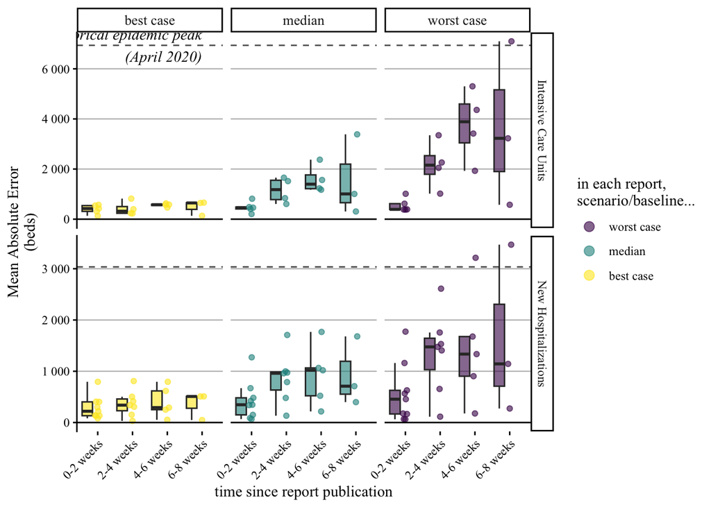

```r
plot_mae_time(temporal, include_constant = FALSE)
```

```r
f_save_graph_pdf_png(
  "graphs/errors_and_uncertainties/MAE_time",
  8, 6, 500
)
```

MAE normalized by beds historical peak; ICU and new hosp MAEs pooled when both exist for 1 report

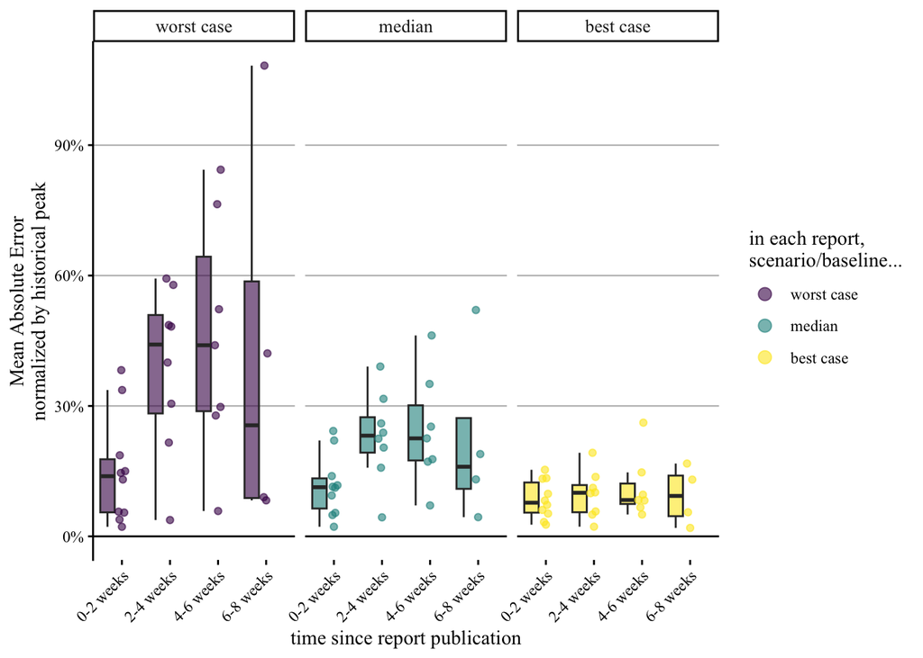

```r
plot_mae_time_pooled_normalized(temporal, include_constant = FALSE)
```

### with baseline

MAE expressed in absolute number of beds, for both ICU and New Hops

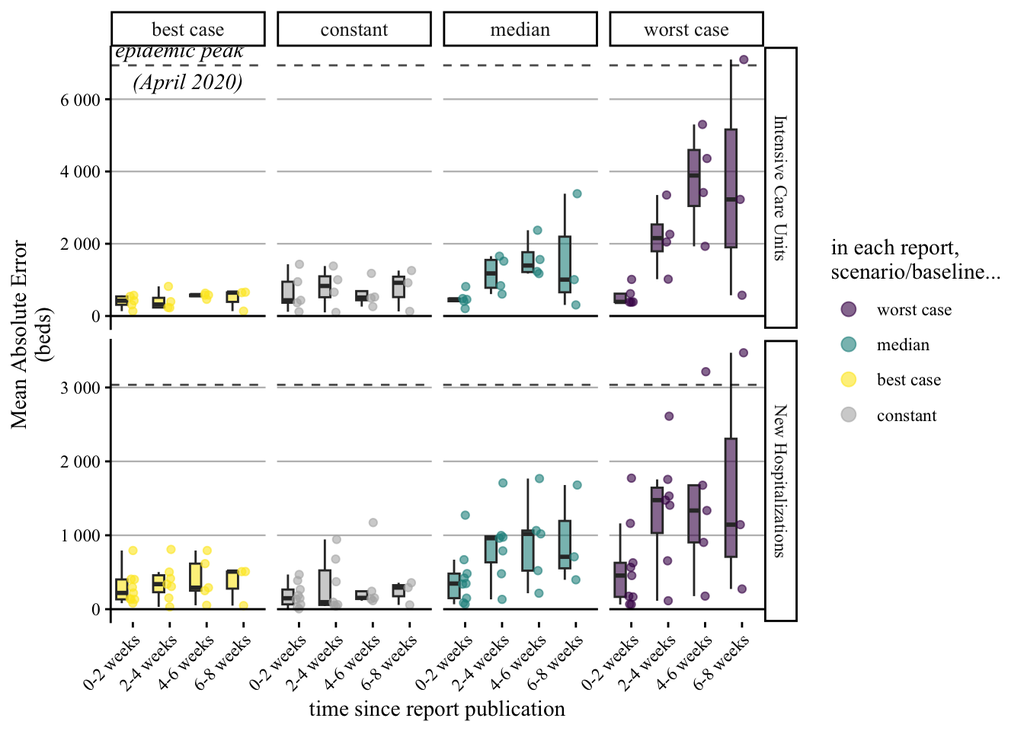

```r
plot_mae_time(temporal, include_constant = TRUE)
```

MAE normalized by beds historical peak; ICU and new hosp MAEs pooled when both exist for 1 report

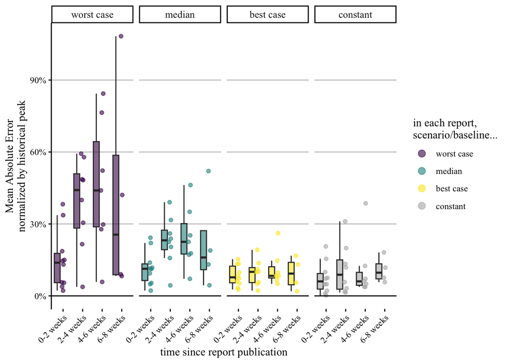

```r
plot_mae_time_pooled_normalized(temporal, include_constant = TRUE)
```

## whole reports period

TBD: ajuster alignement X, explique en subtitle 1 point = 1 scenario dans 1 des 10 rapports

```r
# --- Errors (whole report period): 2 functions mirroring the 2-weeks section ---
# 1) Beds, ICU & New Hosp separated (no pooled)
plot_mae_overall_beds <- function(df, include_constant = TRUE) {

  df <- df %>% filter(endpoint %in% c("Intensive Care Units", "New Hospitalizations"))

  if (include_constant) {
    df_wide <- df %>%
      select(
        scenario_ID, endpoint,
        `MAE (median)`      = `MAE (median, beds)`,
        `MAE (worst case)`  = `MAE (high, beds)`,
        `MAE (best case)`   = `MAE (low, beds)`,
        `MAE (constant)`    = `MAE (constant, beds)`
      )
  } else {
    df_wide <- df %>%
      select(
        scenario_ID, endpoint,
        `MAE (median)`      = `MAE (median, beds)`,
        `MAE (worst case)`  = `MAE (high, beds)`,
        `MAE (best case)`   = `MAE (low, beds)`
      )
  }

  temp <- df_wide %>%
    pivot_longer(
      cols = starts_with("MAE"),
      names_to = "scenario_type",
      values_to = "beds"
    ) %>%
    mutate(
      scenario_type = gsub("^MAE \\(|\\)$", "", scenario_type),
      scenario_type = case_when(
        scenario_type == "worst case" ~ "worst case",
        scenario_type == "median" ~ "median",
        scenario_type == "best case" ~ "best case",
        scenario_type == "constant" ~ "constant",
        TRUE ~ scenario_type
      )
    ) %>%
    filter(!is.na(beds))

  if (include_constant) {
    temp$scenario_type <- factor(temp$scenario_type, levels = c("worst case", "median", "best case", "constant"))
  } else {
    temp$scenario_type <- factor(temp$scenario_type, levels = c("worst case", "median", "best case"))
  }

  scen_cols <- viridisLite::viridis(3)
  cols <- c(
    "worst case" = scen_cols[1],
    "median"     = scen_cols[2],
    "best case"  = scen_cols[3]
  )
  if (include_constant) cols <- c(cols, "constant" = "grey70")

  ggplot(temp) +
    geom_boxplot(
      aes(scenario_type, beds, fill = scenario_type),
      outlier.shape = NA,
      position = position_nudge(y = 0, x = -.3),
      width = .3, alpha = .6
    ) +
    geom_quasirandom(
      aes(scenario_type, beds, color = scenario_type),
      alpha = .6, width = .15
    ) +
    facet_grid(. ~ endpoint, scales = "free_y") +
    scale_fill_manual(values = cols) +
    scale_color_manual(values = cols) +
    geom_hline(yintercept = 0) +
    scale_y_continuous(labels = scales::label_number(drop0trailing = TRUE)) +
    theme(
      axis.line.x = element_blank(),
      axis.text.x = element_text(angle = 45, vjust = 1, hjust = 1),
      strip.text.y = element_blank()
    ) +
    labs(
      x = "scenario in report",
      y = "Mean Absolute Error\n(beds)"
    ) +
    guides(fill = "none", color = "none")
}

# 2) Pooled + normalized (percent y-axis)
plot_mae_overall_pooled_normalized <- function(df, include_constant = TRUE) {

  df <- df %>% filter(endpoint == "pooled ICU and New Hosp")

  # Build the wide table of MAE series to plot (normalized)
  if (include_constant) {
    df_wide <- df %>%
      select(
        scenario_ID,
        `MAE (median)`     = `MAE (median, normalized)`,
        `MAE (worst case)` = `MAE (high, normalized)`,
        `MAE (best case)`  = `MAE (low, normalized)`,
        `MAE (constant)`   = `MAE (constant, normalized)`
      )
  } else {
    df_wide <- df %>%
      select(
        scenario_ID,
        `MAE (median)`     = `MAE (median, normalized)`,
        `MAE (worst case)` = `MAE (high, normalized)`,
        `MAE (best case)`  = `MAE (low, normalized)`
      )
  }

  # Long format
  temp <- df_wide %>%
    pivot_longer(
      cols = starts_with("MAE"),
      names_to = "scenario_type",
      values_to = "mae_norm"
    ) %>%
    mutate(
      scenario_type = gsub("^MAE \\(|\\)$", "", scenario_type)
    ) %>%
    filter(!is.na(mae_norm))

  # Relabel x-axis categories
  temp <- temp %>%
    mutate(
      scenario_type = case_when(
        scenario_type == "worst case" ~ "worst case scenarios\nof reports",
        scenario_type == "median"     ~ "median scenarios\nof reports",
        scenario_type == "best case"  ~ "best case scenarios\nof reports",
        scenario_type == "constant"   ~ "constant baseline\nbenchmark",
        TRUE ~ scenario_type
      )
    )

  # Order categories
  if (include_constant) {
    temp$scenario_type <- factor(
      temp$scenario_type,
      levels = c(
        "worst case scenarios\nof reports",
        "median scenarios\nof reports",
        "best case scenarios\nof reports",
        "constant baseline\nbenchmark"
      )
    )
  } else {
    temp$scenario_type <- factor(
      temp$scenario_type,
      levels = c(
        "worst case scenarios\nof reports",
        "median scenarios\nof reports",
        "best case scenarios\nof reports"
      )
    )
  }

  # Colors: scenarios from viridis, constant in grey
  scen_cols <- viridisLite::viridis(3)
  cols <- c(
    "worst case scenarios\nof reports" = scen_cols[1],
    "median scenarios\nof reports"     = scen_cols[2],
    "best case scenarios\nof reports"  = scen_cols[3]
  )
  if (include_constant) cols <- c(cols, "constant baseline\nbenchmark" = "grey70")

  ggplot(temp) +
    geom_boxplot(
      aes(scenario_type, mae_norm, fill = scenario_type),
      outlier.shape = NA,
      position = position_nudge(y = 0, x = -.3),
      width = .3, alpha = .6
    ) +
    geom_quasirandom(
      aes(scenario_type, mae_norm, color = scenario_type),
      alpha = .6, width = .15
    ) +
    scale_fill_manual(values = cols) +
    scale_color_manual(values = cols) +
    scale_y_continuous(
      labels = scales::percent,
      limits = c(0, NA),
      expand = c(0, 0)
    ) +
    labs(
      x = NULL, y = NULL,
      subtitle = "Mean Absolute Error of scenarios vs reality\n(normalized by historical peak)"
    ) +
    guides(fill = "none", color = "none")
}
```

### without baseline

separate

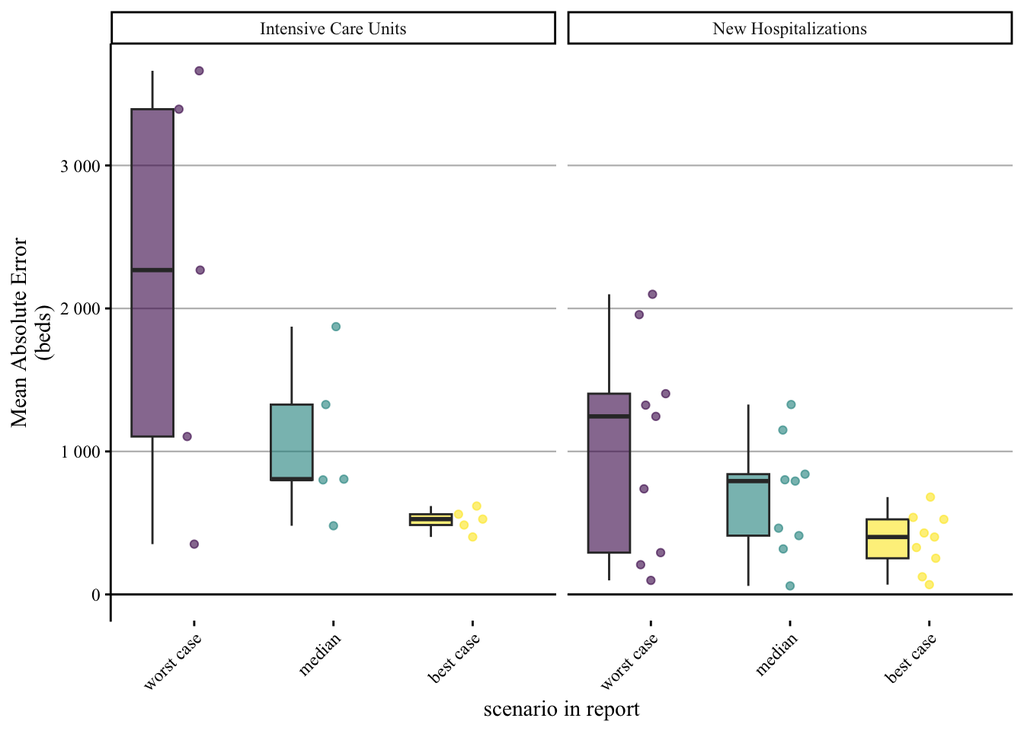

```r
plot_mae_overall_beds(errors, include_constant = FALSE)
```

pooled

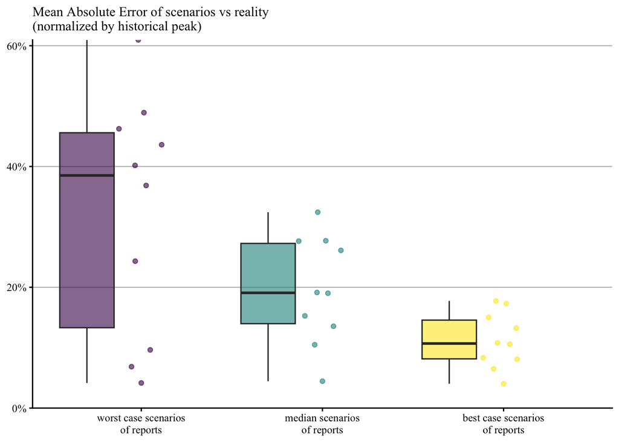

```r
plot_mae_overall_pooled_normalized(errors, include_constant = FALSE)
```

### with baseline

separate

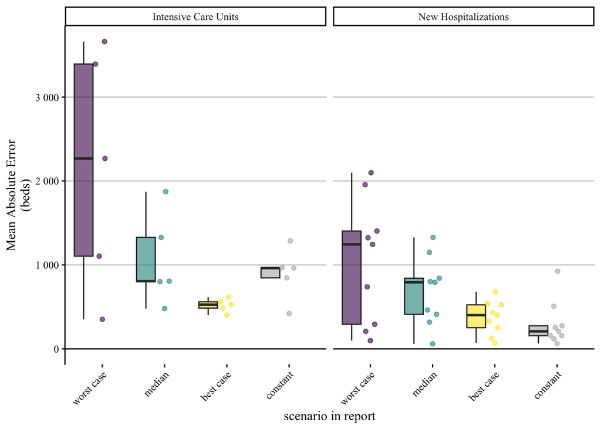

```r
plot_mae_overall_beds(errors, include_constant = TRUE)
```

pooled

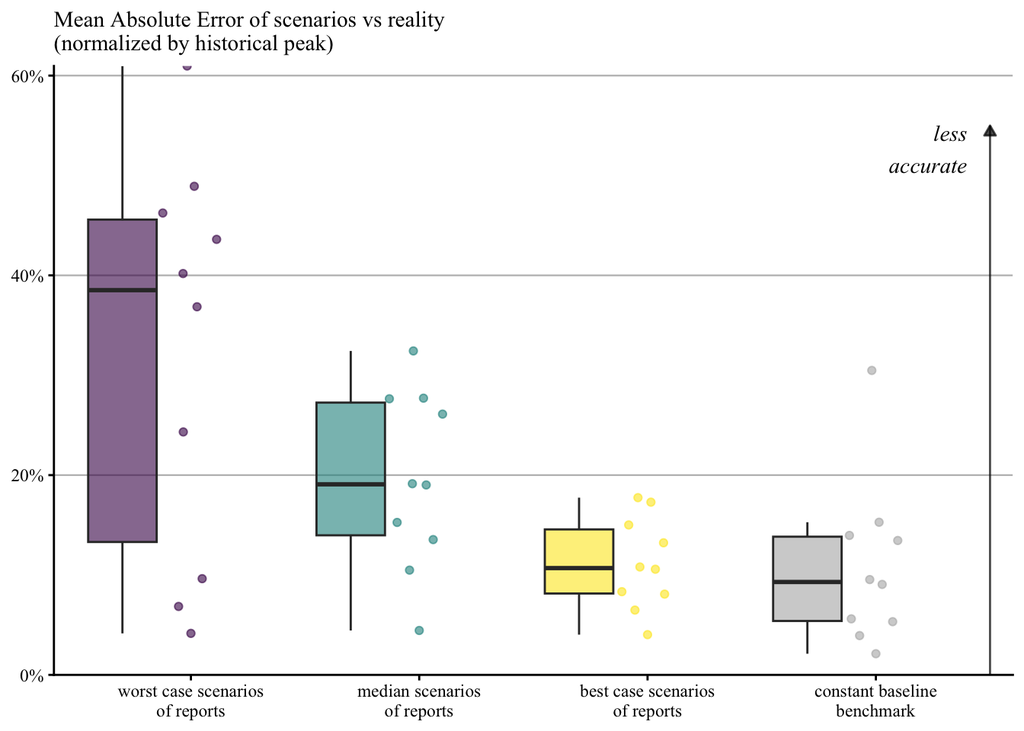

```r
plot_mae_overall_pooled_normalized(errors, include_constant = TRUE) +
    annotate(
      'segment', arrow = arrow(length = unit(0.2, "cm"), type = "closed"),
      x = 4.5, xend = 4.5,
      y = 0,  yend = .55, alpha=.7,
      ) +
    annotate(
      "text", label="less\naccurate", family="Times New Roman", fontface="italic",
      x=4.4, y=.55, vjust=1, hjust=1
    )
```

```r
f_save_graph_pdf_png(
  "graphs/errors_and_uncertainties/MAE_norm",
  5, 3, 500
)
```

# Bias

## Error Bias (Mean Error)

When a report has scenarios relating to both ICU and new hospitalizations, we take the mean of the 2.

```r
# old
# temp <- errors_old %>%
#   select(scenario_ID, scenario_type, `Mean Error (%)`) %>%
#   group_by(scenario_ID, scenario_type) %>%
#   summarise(
#     `Mean Error (%)` = mean(`Mean Error (%)`)
#     )
# temp$scenario_type <- fct_recode(
#   temp$scenario_type,
#   `worst case scenarios\nof reports` = "worst case",
#   `median scenarios\nof reports` = "median",
#   `best case scenarios\nof reports` = "best case"
#   )
#
# (g1 <- ggplot(temp) +
#     geom_boxplot(
#       aes(scenario_type, `Mean Error (%)`, fill=scenario_type),
#       position = position_nudge(y = 0, x = -.3),
#       outlier.shape = NA,
#       width=.2, alpha=.6
#       ) +
#     geom_quasirandom(
#         aes(scenario_type, `Mean Error (%)`, color=scenario_type),
#         alpha=.6, width=.1
#         ) +
#     scale_y_continuous(
#       labels = scales::percent,
#       limits=c(-.8, .8),
#       breaks = seq(-.75, .75, .25)
#       ) +
#     labs(
#       x='',
#       y='Mean Error'
#       ) +
#     scale_fill_viridis_d() +
#     scale_color_viridis_d() +
#     theme(legend.position = 'none') +
#     geom_hline(yintercept=0, linetype='dashed') +
#     annotate(
#       'segment', arrow = arrow(length = unit(0.2, "cm"), type = "closed"),
#       x = 3.1, y = 0.1, xend = 3.1, yend = .7,  alpha=.5
#       ) +
#     annotate(
#       'segment', arrow = arrow(length = unit(0.2, "cm"), type = "closed"),
#       x = 3.1, y = -0.1, xend = 3.1, yend = -.7, alpha=.5
#       ) +
#     annotate(
#       "text", x = 3.15, y = .1, label = "unbiased", hjust=0,
#       fontface = "italic", family = "Times New Roman",
#       ) +
#     annotate(
#       "text", x = 3, y = -.7, label = "too\noptimistic", hjust=1, vjust=0,
#       fontface = "italic", family = "Times New Roman",
#       ) +
#     annotate(
#       "text", x = 3, y = .7, label = "too\npessimistic", hjust=1, vjust=1,
#       fontface = "italic", family = "Times New Roman",
#       )
# )
#
```

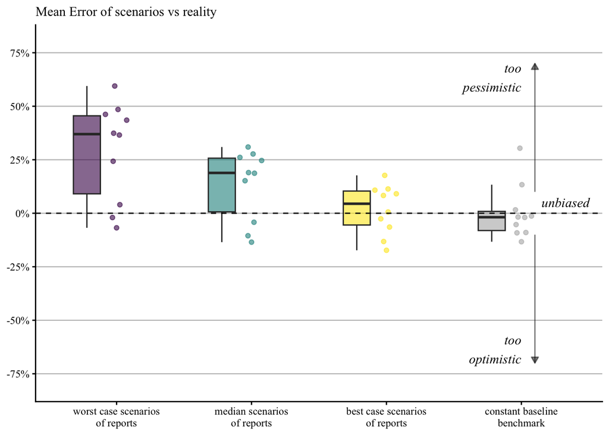

```r
temp <- errors_new %>%
  filter(scenario_type %in% c("worst case", "median", "best case", "constant")) %>%
  select(scenario_ID, scenario_type, `Mean Error (%)`) %>%
  group_by(scenario_ID, scenario_type) %>%
  summarise(
    `Mean Error (%)` = mean(`Mean Error (%)`),
    .groups = "drop"
  )

temp$scenario_type <- fct_recode(
  temp$scenario_type,
  `worst case scenarios\nof reports` = "worst case",
  `median scenarios\nof reports`     = "median",
  `best case scenarios\nof reports`  = "best case",
  `constant baseline\nbenchmark`    = "constant"
)

temp$scenario_type <- factor(
  temp$scenario_type,
  levels = c(
    "worst case scenarios\nof reports",
    "median scenarios\nof reports",
    "best case scenarios\nof reports",
    "constant baseline\nbenchmark"
  )
)

# Colors: scenarios from viridis, constant in grey
scen_cols <- viridisLite::viridis(3)
cols <- c(
  "worst case scenarios\nof reports" = scen_cols[1],
  "median scenarios\nof reports"     = scen_cols[2],
  "best case scenarios\nof reports"  = scen_cols[3],
  "constant baseline\nbenchmark"    = "grey70"
)

(g1 <- ggplot(temp) +
   geom_boxplot(
     aes(scenario_type, `Mean Error (%)`, fill = scenario_type),
     position = position_nudge(y = 0, x = -.22),
     outlier.shape = NA,
     width = .2, alpha = .6
   ) +
   geom_quasirandom(
     aes(scenario_type, `Mean Error (%)`, color = scenario_type),
     alpha = .6, width = .1
   ) +
   scale_y_continuous(
     labels = scales::percent,
     limits = c(-.8, .8),
     breaks = seq(-.75, .75, .25)
   ) +
   labs(
     x = NULL, y=NULL,
     subtitle = "Mean Error of scenarios vs reality"
   ) +
   scale_fill_manual(values = cols) +
   scale_color_manual(values = cols) +
   theme(legend.position = "none") +
   geom_hline(yintercept = 0, linetype = "dashed") +
   annotate(
     "segment", arrow = arrow(length = unit(0.2, "cm"), type = "closed"),
     x = 4.1, y = 0.1, xend = 4.1, yend = .7, alpha = .5
   ) +
   annotate(
     "segment", arrow = arrow(length = unit(0.2, "cm"), type = "closed"),
     x = 4.1, y = -0.1, xend = 4.1, yend = -.7, alpha = .5
   ) +
   annotate(
     "text", x = 4.15, y = .05, label = "unbiased", hjust = 0,
     fontface = "italic", family = "Times New Roman"
   ) +
   annotate(
     "text", x = 4, y = -.7, label = "too\noptimistic", hjust = 1, vjust = 0,
     fontface = "italic", family = "Times New Roman"
   ) +
   annotate(
     "text", x = 4, y = .7, label = "too\npessimistic", hjust = 1, vjust = 1,
     fontface = "italic", family = "Times New Roman"
   )
)
```

```r
f_save_graph_pdf_png(
  "graphs/errors_and_uncertainties/bias_mean_error",
  5.9, 3, 500
)
```

## Self-assessment bias

### detailed with dates

```r
#small offset to position adjacent reports labels on x axis
reports_date <-  data.frame(
  positions = unique(as.Date(gsub("Scenario: ", "", errors$scenario_ID))),
  labels = unique(as.Date(gsub("Scenario: ", "", errors$scenario_ID)))
)
#Aug and Jul 2021
reports_date$positions[reports_date$labels=="2021/07/26"] <- reports_date$positions[reports_date$labels=="2021/07/26"] -10
reports_date$positions[reports_date$labels=="2021/08/05"] <- reports_date$positions[reports_date$labels=="2021/08/05"] +10
#Apr and May 2021
reports_date$positions[reports_date$labels=="2021-04-26"] <- reports_date$positions[reports_date$labels=="2021-04-26"] -5
reports_date$positions[reports_date$labels=="2021-05-21"] <- reports_date$positions[reports_date$labels=="2021-05-21"] +5
#Feb 2021
reports_date$positions[reports_date$labels=="2021-02-08"] <- reports_date$positions[reports_date$labels=="2021-02-08"] -8
reports_date$positions[reports_date$labels=="2021-02-14"] <- reports_date$positions[reports_date$labels=="2021-02-14"]+1
reports_date$positions[reports_date$labels=="2021-02-23"] <- reports_date$positions[reports_date$labels=="2021-02-23"] +8
```

```r
g_self_assessment_bias <- function(
    error_df, error_metric, y_low_annotation, y_top_annotation, y_lim){

  #prepare data
  temp <- error_df %>%
    select(scenario_ID, error = !!as.symbol(error_metric), scenario_type, `Self-assessment by modelers`) %>%
    group_by(scenario_ID, scenario_type, `Self-assessment by modelers`) %>% #when both endpoint reports, take the mean of the 2
    summarise(
      error = mean(error)
      ) %>%
    mutate(
      scenario_ID = gsub("Scenario: ", "", scenario_ID)
    ) %>%
    spread(
      scenario_type, error
    )

  #main graph
  pmain <- ggplot(temp) +
    #dates of reports on x axis
    geom_rug(aes(as.Date(scenario_ID))) +
    #error line and points
    geom_pointrange(
      aes(
        y=median, ymin=`best case`, ymax=`worst case`, x=as.Date(scenario_ID),
        color=`Self-assessment by modelers`
        ),
      size=.4, linewidth=1, shape=16
      ) +
    #colors assessed by modelers or not
    scale_color_manual(
      values = c(
        "Yes" = alpha("#1e8449", 1),
        "No" = alpha("#900C3F", .2)
        )
      ) +
    #arrow and accuracy annotation
    annotate(
      'segment', arrow = arrow(length = unit(0.2, "cm"), type = "closed"),
      x = as.Date("2022-04-01"), xend = as.Date("2022-04-01"),
      y = y_low_annotation,  yend = y_top_annotation, alpha=.7,
      ) +
    annotate(
      "text", label="accurate", family="Times New Roman", fontface="italic",
      x=as.Date("2022-04-01"),
      y=y_low_annotation, vjust=1,
    ) +
    annotate(
      "text", label="unaccurate", family="Times New Roman", fontface="italic",
      x=as.Date("2022-04-01"),
      y=y_top_annotation, vjust=-0.3
    ) +
    #graph parameters
    scale_y_continuous(
      labels = scales::percent #% notation on y axis
      ) +
    scale_x_continuous(#labels of reports
      breaks = reports_date$positions,
      labels = format(reports_date$labels, format="%b %d, %Y")
    ) +
    coord_cartesian(
      xlim = c(as.Date("2020-10-01"), as.Date("2022-05-01")),
      ylim = c(0, y_lim)
      ) +
    theme(
      axis.text.x = element_text(angle = 45, vjust = 1, hjust=1),
      axis.ticks.x=element_blank(),
      legend.position = c(.2, .75),
      legend.background = element_rect(fill=alpha('white', .7), color="grey")
      ) +
    labs(
      x="",
      y="Mean Absolute Error",
      color="scenarios\nself-assessed\nby modelers?"
      )

    #side boxplot
    ydens <- axis_canvas(pmain, axis = "y", coord_flip = TRUE) +
      geom_boxplot(
        data = temp,
        aes(x = median, fill=`Self-assessment by modelers`),
        alpha = 0.5, size = 0.2, linewidth=.5, outlier.shape = 4
        ) +
      xlim(0, y_lim) +
      scale_fill_manual(
        values = c(
          "Yes" = alpha("#1e8449", 1),
          "No" = alpha("#900C3F", .2)
          )
        ) +
      coord_flip()

  return(list(pmain, ydens))

}
```

```r
temp <- read_csv('results/error_metrics_including_illegitimate_comparisons.csv', show_col_types = F) %>%
  rename(
    scenario_ID = Date,
    endpoints = Endpoint
  ) %>%
  #for % on graph
  mutate(
    across(
      c(`MAPE (median)`, `MAPE (optimist)`, `MAPE (pessimist)`, `MAE (median)`, `MAE (optimist)`, `MAE (pessimist)`, ),
      ~.x/100
      )
    ) %>%
  gather(
    error_scenario, percent, `MAE (median)`:`MAPE (pessimist)`
    ) %>%
  separate(error_scenario, sep = " ", into=c("error_metric", "scenario_type")) %>%
  spread(error_metric, percent)

temp$scenario_type = factor(temp$scenario_type)
temp$scenario_type = fct_recode(
  temp$scenario_type,
  `median` = "(median)", `best case` = "(optimist)", `worst case` = "(pessimist)"
  )

temp <- temp %>%
  rename(
    `Mean Absolute Error (%)` = MAE,
    `Mean Absolute Percentage Error` = MAPE
    )
```

### TBD simple

```r
test <- temp %>%
  select(`MAE (median, beds)`, `MAE (low, beds)`, `MAE (high, beds)`, scenario_ID, endpoints, `Self-assessment by modelers`) %>%
  gather(metric, value, `MAE (median, beds)`, `MAE (low, beds)`, `MAE (high, beds)`) %>%
  distinct()

test <- test %>%
  mutate(
    # Normalize by endpoint-specific max (as a proportion)
    value = case_when(
      endpoints == "New hosp." ~ value / max_new_hosp,
      endpoints == "ICU"       ~ value / max_ICU_beds,
      TRUE                     ~ NA_real_
    )
  ) %>%
  group_by(scenario_ID, `Self-assessment by modelers`) %>%
  summarise(
    # Average across endpoints within each scenario x self-assessed
    value = mean(value, na.rm = TRUE),
    .groups = "drop"
  ) %>%
  mutate(
    `Self-assessment by modelers` =
      factor(`Self-assessment by modelers`, levels = c("No", "Yes"))
    )

# Wilcoxon rank-sum test.
w <- wilcox.test(value ~ `Self-assessment by modelers`, data = test, exact = TRUE)
w # see result
```

```
##
##  Wilcoxon rank sum exact test
##
## data:  value by Self-assessment by modelers
## W = 26, p-value = 0.01818
## alternative hypothesis: true location shift is not equal to 0
```

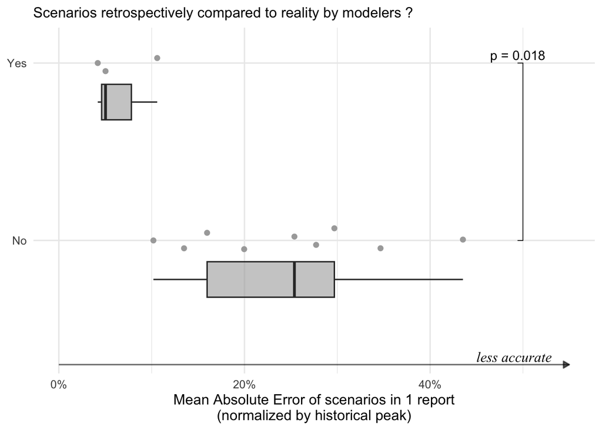

```r
ggplot(test, aes(x = `Self-assessment by modelers`, y = value)) +
  geom_boxplot(
    position = position_nudge(y = 0, x = -.22),
    outlier.shape = NA, fill="darkgrey",
    width = .2, alpha = .6) +
  geom_quasirandom(
    alpha=1, width=.1, color="darkgrey"
    ) +
  scale_y_continuous(
    labels = scales::percent,
    limits = c(0, .55)
    ) +
  stat_pvalue_manual(
    data = data.frame(
      group1 = "No",
      group2 = "Yes",
      y.position = .5,
      p = round(w$p.value, 3)
    ),
    label = "p = {p}",
    tip.length = 0.01
  ) +
  labs(
    subtitle="Scenarios retrospectively compared to reality by modelers ?",
    x=NULL, y = "Mean Absolute Error of scenarios in 1 report\n(normalized by historical peak)"
    ) +
  theme_minimal(base_size = 12) +
  coord_flip() +
  annotate(
    geom="segment", x = 0.3, xend = 0.3, y = 0, yend = .55,
    arrow = arrow(length = unit(0.2, "cm"), type = "closed"),
    alpha=.6
    ) +
  annotate(
    geom="text", x = 0.3, y = .45, family = "Times New Roman",
    fontface = "italic", label="less accurate",
    vjust=-0.3, hjust=0
    ) +
  scale_x_discrete(expand = expansion(mult = c(.75, 0.2)))
```

```r
f_save_graph_pdf_png(
  "graphs/errors_and_uncertainties/self_assessment_stat_test",
  6, 4, 500
)
```

### MAPE

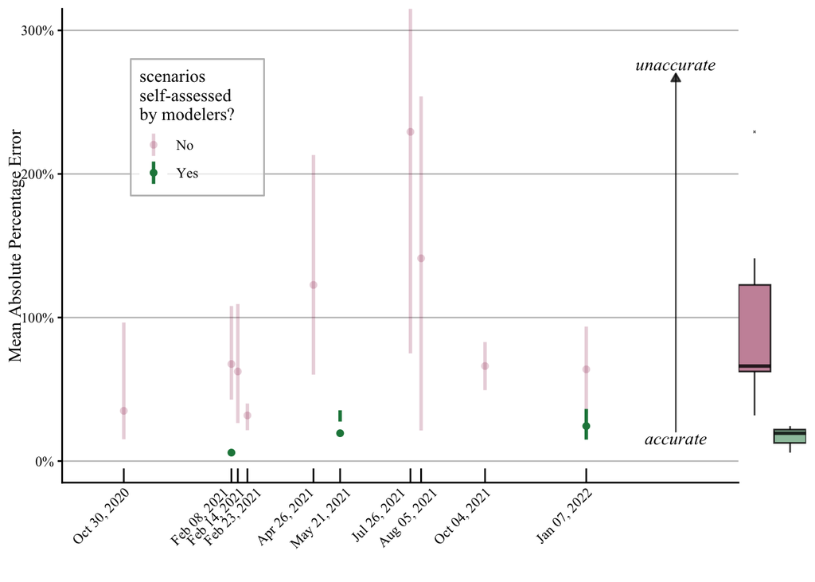

```r
g2 <- insert_yaxis_grob(
  g_self_assessment_bias(temp, "Mean Absolute Percentage Error", .2, 2.7, 3)[[1]] +
    labs(y="Mean Absolute Percentage Error"),
  g_self_assessment_bias(temp, "Mean Absolute Percentage Error", .2, 2.7, 3)[[2]],
  grid::unit(.1, "null"), position = "right"
  )
(ggdraw(g2))
```

```r
f_save_graph_pdf_png(
  "graphs/errors_and_uncertainties/self_assessment_bias_MAPE",
  6, 4, 500
)
```

### MAE

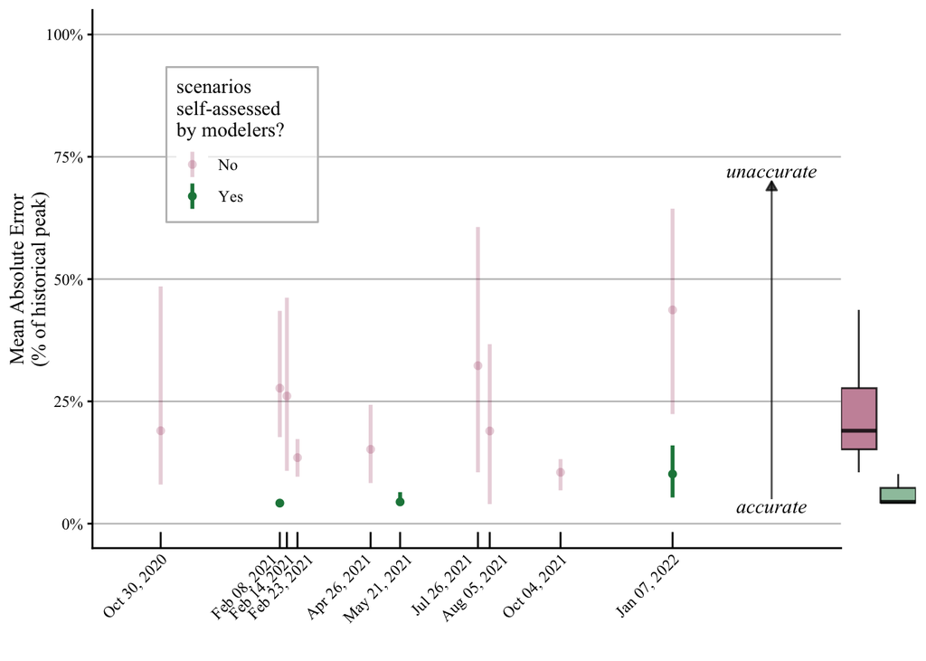

```r
g <- insert_yaxis_grob(
  g_self_assessment_bias(temp, "Mean Absolute Error (%)", .05, 0.7, 1)[[1]] +
    labs(y="Mean Absolute Error\n(% of historical peak)"),
  g_self_assessment_bias(temp, "Mean Absolute Error (%)", .05, 0.7, 1)[[2]],
  grid::unit(.1, "null"), position = "right"
  )
(ggdraw(g))
```

```r
f_save_graph_pdf_png(
  "graphs/errors_and_uncertainties/self_assessment_bias_MAE",
  6, 4, 500
)
rm(g)
```

## Both graphs

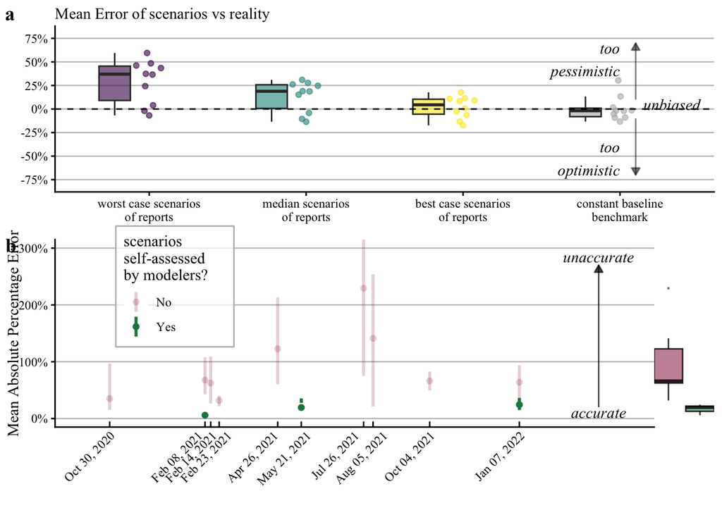

```r
plot_grid(
  g1, g2, nrow=2, rel_heights = c(.45, .55),
  labels = c("a", "b"), axis="l", align="v"
  )
```

```r
f_save_graph_pdf_png(
  "graphs/errors_and_uncertainties/biases",
  6, 6, 500
)

rm(reports_date, g1, g2)
```

# Uncertainty

## pooled

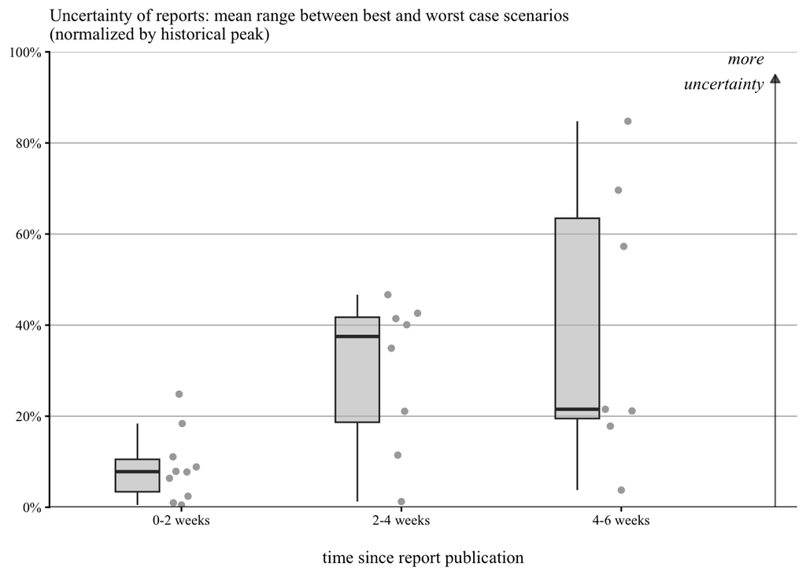

```r
temp <- temporal %>%
  select(scenario_ID, endpoint, Period, `Average uncertainty (normalized)`) %>%
  filter(endpoint == "pooled ICU and New Hosp") %>%
  filter(Period != "6-8 weeks") # too feww reports

ggplot(temp) +
  geom_boxplot(
    aes(Period, `Average uncertainty (normalized)`),
    position = position_nudge(y = 0, x = -.2),
    outlier.shape = NA, fill="grey",
    width=.2, alpha=.6
    ) +
  geom_quasirandom(
    aes(Period, `Average uncertainty (normalized)`),
    alpha=1, width=.1, color="darkgrey"
    ) +
  labs(
    x='\ntime since report publication', y=NULL,
    subtitle = "Uncertainty of reports: mean range between best and worst case scenarios\n(normalized by historical peak)"
    ) +
  scale_y_continuous(
    labels = scales::percent,
    breaks= seq(0, 1, .2),
    limits = c(0, 1),
    expand = expansion(mult = c(0, 0))
  ) +
  theme(
    axis.line.x=element_blank(),
    strip.text.y = element_blank(),
    legend.position = "none"
    ) +
  geom_hline(yintercept = 0) +
  annotate(
    geom="segment", x = 3.7, xend = 3.7, y = 0, yend = .95,
    arrow = arrow(length = unit(0.2, "cm"), type = "closed"),
    alpha=.6
    ) +
  annotate(
    geom="text", x = , 3.65, y = 1, family = "Times New Roman",
    fontface = "italic", label="more\nuncertainty",
    vjust=1, hjust=1
    ) +
  coord_cartesian(
    xlim = c(NA, 3.2)
    )
```

```r
f_save_graph_pdf_png(
  "graphs/errors_and_uncertainties/uncertainties_pooled",
  5.2, 3.5, 500
)
```

## ICU and new hosp

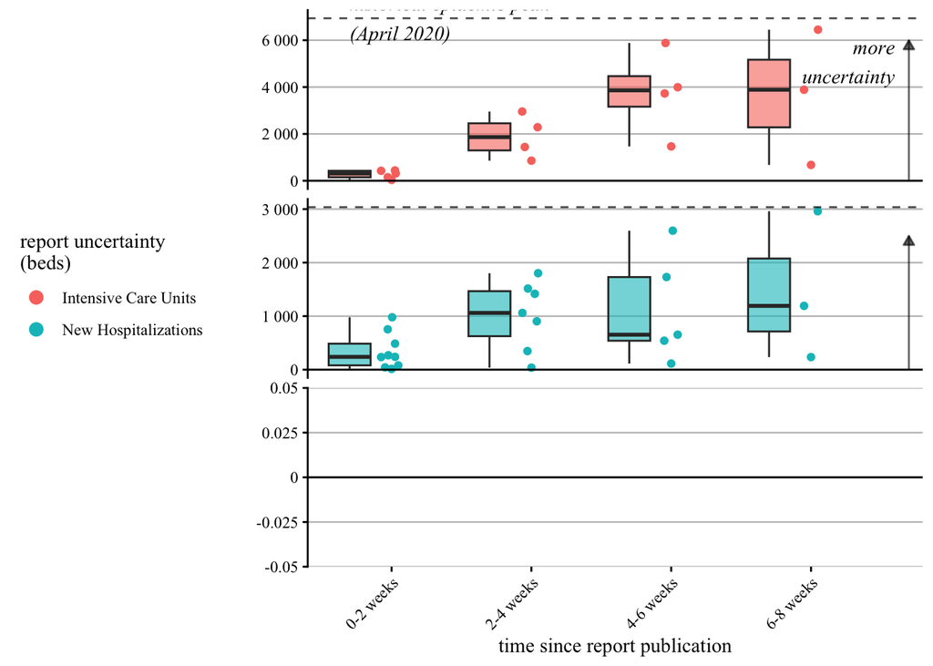

```r
temp <- temporal %>%
  select(scenario_ID, endpoint, Period, `Average uncertainty (beds)`)

x_arrow <- 4.7
x_label_uncertain <- 4.6
x_label_peak <- .7
y_arrow_ICU <- 6000
y_arrow_hosp <- 2500

hline_dat = data.frame(
  endpoint=c("Intensive Care Units", "New Hospitalizations"),
  beds=c(max_ICU_beds, max_new_hosp)
  )

vline_dat = data.frame(
  endpoint=c("Intensive Care Units", "New Hospitalizations"),
  x=c(x_arrow, x_arrow),
  xend=c(x_arrow, x_arrow),
  y=c(0, 0),
  yend=c(y_arrow_ICU, y_arrow_hosp)
  )

label_dat = data.frame(
  label=c("more\nuncertainty", "historical epidemic peak\n(April 2020)"),
  endpoint=c("Intensive Care Units", "Intensive Care Units"),
  x=c(x_label_uncertain, x_label_peak),
  y=c(y_arrow_ICU, max_ICU_beds)
  )

ggplot(temp) +
  geom_boxplot(
    aes(Period, `Average uncertainty (beds)`, fill=endpoint),
    position = position_nudge(y = 0, x = -.3),
    outlier.shape = NA,
    width=.3, alpha=.6
    ) +
  geom_quasirandom(
    aes(Period, `Average uncertainty (beds)`, color=endpoint),
    alpha=1, width=.1
    ) +
  labs(
    x='time since report publication',
    y='',
    fill="report uncertainty\n(beds)",
    color="report uncertainty\n(beds)"
    ) +
  guides(
    fill="none",
    color = guide_legend(override.aes = list(size = 3))
    ) +
  scale_y_continuous(
    labels = scales::label_number(drop0trailing = TRUE)
  ) +
  theme(
    axis.line.x=element_blank(),
    strip.text.y = element_blank(),
    axis.text.x = element_text(angle = 45, vjust = 1, hjust=1),
    legend.position = "left"
    ) +
  # annotate(
  #   "text", x = 3, y = 1, label = "historical maximum\nbed occupancy peak", hjust=1,
  #   fontface = "italic", family = "Times New Roman"
  #   ) +
  facet_grid(vars(endpoint), scales="free_y") +
  geom_hline(
    data=hline_dat,
    aes(yintercept=beds),
    linetype="dashed", alpha=.7
    ) +
  geom_hline(
    yintercept=0,
    ) +
  geom_segment(
    data=vline_dat,
    aes(x=x, xend=xend, y=y, yend=yend),
    arrow = arrow(length = unit(0.2, "cm"), type = "closed"),
    alpha=.6
    ) +
  geom_text(
    data=label_dat,
    aes(x=x, y=y, label=label, vjust=c(1, 0.5), hjust=c(1, 0)),
    fontface = "italic", family = "Times New Roman",
    ) +
  coord_cartesian(
    xlim = c(NA, 4.2)
    )
```

```r
f_save_graph_pdf_png(
  "graphs/errors_and_uncertainties/uncertainties",
  8, 6, 500
)

rm(temp, hline_dat, vline_dat, x_arrow, x_label, x_label_peak, x_label_uncertain, y_arrow_hosp, y_arrow_hosp, label_dat)

#old code without temporal evolution

# temp <- uncertainties %>%
#
#   select(scenario_ID,`Average uncertainty`, `Max uncertainty`) %>%
#   group_by(scenario_ID) %>% #when both endpoint reports, take hte mean of the 2
#   summarise(
#     `Average uncertainty` = mean(`Average uncertainty`),
#     `Max uncertainty` = mean(`Max uncertainty`),
#     ) %>%
#   rename(
#     `Average\nUncertainty` = `Average uncertainty`,
#     `Maximum\nUncertainty` = `Max uncertainty`,
#     ) %>%
#   gather(
#     key=indicator, value=percentage, `Average\nUncertainty`, `Maximum\nUncertainty`
#     ) %>%
#   mutate(
#     percentage = percentage/100 #to have percentages on graph
#   )
#
# ggplot(temp) +
#   geom_boxplot(
#     aes(indicator, percentage),
#     position = position_nudge(y = 0, x = -.3),
#     outlier.shape = NA,
#     width=.2, alpha=.6
#     ) +
#   geom_quasirandom(
#     aes(indicator, percentage),
#     alpha=.6, width=.1
#     ) +
#   scale_y_continuous(
#     labels = scales::percent,
#     breaks=c(seq(0, max(temp$percentage), .25))
#     ) +
#   labs(
#     x='',
#     y='reports uncertainty'
#     ) +
#   theme(legend.position = 'none') +
#   geom_hline(yintercept=1, linetype='dashed') +
#   annotate(
#     "text", x = 3, y = 1, label = "historical maximum\nbed occupancy peak", hjust=1,
#     fontface = "italic", family = "Times New Roman"
#     )
```

# Other Absolute Errors

## Absolute mean and max error (MAE)

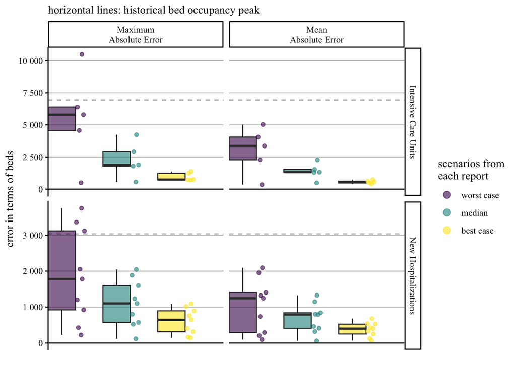

```r
temp <- errors_old %>%
  select(
    scenario_ID,
    scenario_type,
    endpoints,
    `Maximum\nAbsolute Error`=`Maximum Error (beds)`,
    `Mean\nAbsolute Error`= `Mean Absolute Error (beds)`
    ) %>%
  gather(
    key=indicator, value=percentage,
    `Maximum\nAbsolute Error`, `Mean\nAbsolute Error`
    )

hline_dat = data.frame(
  endpoints=c("Intensive Care Units", "New Hospitalizations"),
  beds=c(max_ICU_beds, max_new_hosp)
  )

(g2 <- ggplot(temp) +
    geom_boxplot(
      aes(scenario_type, percentage, fill=scenario_type),
      position = position_nudge(y = 0, x = -.35),
      outlier.shape = NA, width=.5, alpha=.6
      ) +
    geom_quasirandom(
        aes(scenario_type, percentage, color=scenario_type),
        alpha=.6, width=.1,
        ) +
    geom_hline(
      data=hline_dat,
      aes(yintercept=beds),
      linetype="dashed", alpha=.4
      ) +
    facet_grid(endpoints~indicator, scales = "free") +
    labs(
      x='',
      y='error in terms of beds',
      color="scenarios from\neach report",
      fill="scenarios from\neach report",
      subtitle = "horizontal lines: historical bed occupancy peak"
      ) +
    guides(
      fill="none",
      color = guide_legend(override.aes = list(size = 3))
      ) +
    scale_fill_viridis_d() +
    scale_color_viridis_d() +
    scale_y_continuous(
      labels = scales::label_number(drop0trailing = TRUE)
    ) +
    theme(
      axis.text.x = element_blank(),
      axis.ticks.x = element_blank(),
      axis.line.x = element_blank()
    ) +
    geom_hline(yintercept = 0)
)
```

```r
rm(temp, hline_dat)

#save
f_save_graph_pdf_png(
  "graphs/errors_and_uncertainties/mean_max_beds_error",
  6, 4, dpi_resolution
)
```

```r
rm(list = ls())
```